# Choosing a pension plan: An investor’s advanced decision tool

Martin Hoshi Vognsen

21:52 25 June 2026

# Purpose

This tool is the decision companion to the diagnostic report *Monthly pension returns analysis*, which serves as its technical appendix. That report establishes how each plan’s returns are distributed and why the methods used below are the right ones; this tool applies them to your data and costs and turns them into the two decisions an investor actually faces:

1. **Which risk level** – and is a higher-risk plan anything more than a more-leveraged version of a lower-risk one?
2. **One provider or both** – is there diversification between PFA and Velliv, and could it plausibly beat the cost of splitting?

The returns reports’ central caveat governs everything here: With about 12 years of data and fat tails, point estimates (means, Sharpe ratios, correlations) are noisy and regime-dependent. The tool is therefore built to expose *how robust* each conclusion is, not to emit a single “best” plan. Returns are monthly, 142 months (2012-07 to 2024-04). Sharpe ratios use the risk-free rate set in the inputs below.

Every figure below is computed from your data and these settings. Change them in the YAML header at the top of this document, or pass them as render parameters.

Current inputs. Sharpe ratios, certainty equivalents, fee break-evens and the stress simulation all read from these.

| setting | value |
| --- | --- |
| Balance (kr) | 1,000,000 |
| Flat fee per provider (kr/yr) | 700 |
| Proportional fee, Velliv | 0.70% |
| Proportional fee, PFA | 0.70% |
| Risk-free rate (annual) | 0.0% |
| Risk aversion | 2 |
| Horizon (years) | 20 |
| Start date | full comparable window |
| Monitor window (months) | 36 |
| Assumed tail index | 3.5 |
| Assumed skew | 0.7 |

# 1. Current regime check

The reports’ working model is a heavy-tailed, left-skewed return distribution. Before any mean-variance figure can be trusted, check whether the loaded data still look that way or have moved toward the Gaussian. A skewed-t fit answers it: A high tail index `nu` with a skew `xi` near 1 is near-Gaussian; a low `nu`, or a `xi` below 1, is heavy tails and left skew.

Skewed-t fit per plan on the loaded data. A low tail index (heavy tails) or a skew below 1 (left skew) is the reports’ regime; a high tail index with skew near 1 is near-Gaussian.

| plan | tail index $\nu$ | $\nu$ SE | skew $\xi$ | $\xi$ SE |
| --- | --- | --- | --- | --- |
| Velliv medium | 3.4 | 1.2 | 0.70 | 0.09 |
| Velliv high | 3.5 | 1.2 | 0.71 | 0.09 |
| PFA B | 3.5 | 1.2 | 0.77 | 0.08 |
| PFA high (D) | 4.0 | 1.5 | 0.74 | 0.08 |

Across these plans the median tail index is 3.5 and the median skew is 0.72. That is firmly heavy-tailed, the regime the reports assume, so the mean-variance figures here are body-of-distribution summaries and the tail caveats stand.

The test is deliberately asymmetric. A single extreme month can reveal a fat tail; no stretch of calm can prove its absence.

The latest month (2024-04) is within the fitted tails of every plan: No fresh tail signal, which on its own proves nothing. Calling the regime Gaussian instead needs far more data than a benign stretch provides. The tail parameters are not pinned down at 142 observations: By the reports’ analysis, matching even 30 Gaussian observations for the *mean* takes on the order of 118 heavy-tailed observations, and the tail needs more still. Treat a quiet tail as unproven, not safe.

# 2. Within a provider: Which risk level?

A higher-risk plan is *pure leverage* of a lower-risk one when it has the same reward-to-risk (Sharpe) and the same distributional shape, only scaled. If so, choosing a risk level is a pure risk-appetite dial with no consequence for return-per-unit-risk. We test this with the Sharpe ratio of each plan and, crucially, its stability across sub-periods.

Annualised Sharpe ratio by plan and start date.

|  | Velliv low | Velliv med | Velliv high | PFA low (A) | PFA B | PFA C | PFA high (D) |
| --- | --- | --- | --- | --- | --- | --- | --- |
| from 2012-07 (n=142) | 0.82 | 0.84 | 0.81 | 1.05 | 1.06 | 1.04 | 1.01 |
| from 2016-05 (n=96) | 0.64 | 0.68 | 0.67 | 0.67 | 0.76 | 0.80 | 0.80 |
| from 2020-05 (n=48) | 0.66 | 0.72 | 0.79 | 0.48 | 0.77 | 0.94 | 1.02 |

The table samples three start dates. The plot below sweeps every start date that leaves at least two years of data to the same fixed end, with 95% confidence bands. Look for whether a provider’s plans have overlapping bands: Where they do, the plans cannot be told apart on reward-per-risk.

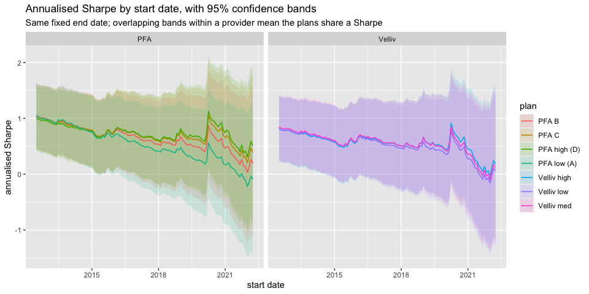

**Velliv.** The three plans’ Sharpe ratios (around 0.8) span 0.03 against a sampling error of about 0.29. That spread is within the noise, so on this data Velliv behaves as a leverage ray. Choosing a Velliv risk level is then a pure risk-appetite decision, with nothing to optimise.

**PFA.** The four profiles’ Sharpe ratios span 0.05 against a sampling error of about 0.3, so the menu is, within the noise, also a single ray. The highest-Sharpe profile by start window is PFA B from 2012-07; PFA C from 2016-05; PFA high (D) from 2020-05, and it is not stable across windows. So no best-Sharpe blend is reliably identifiable, and you should not pay, in added risk or in fees, to chase one.

The same test reads off the risk-return map. Each plan sits at its annualised volatility and mean return; plans on one line from the risk-free rate share a Sharpe ratio, and a plan off that line differs in reward-per-risk. Look for whether each provider’s plans line up.

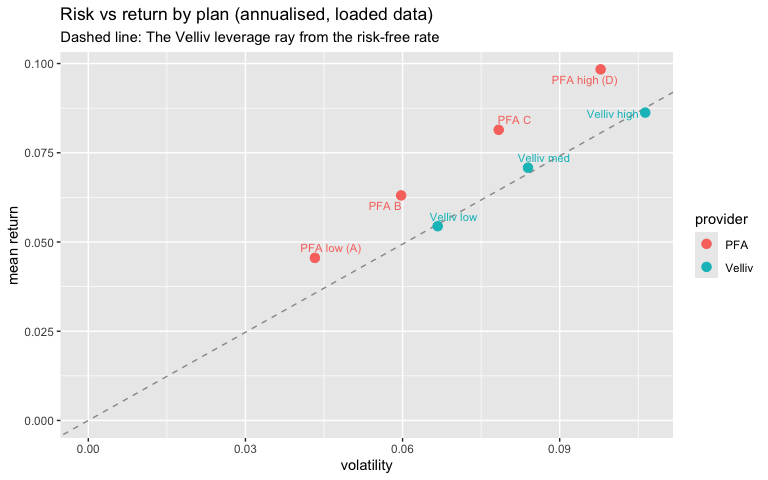

The derivation of the ray and its sampling error is in the Sharpe ratio section of the diagnostic report.

# 3. Across providers: Is there diversification?

Correlation matrix of monthly returns across all plans.

|  | Velliv low | Velliv med | Velliv high | PFA low (A) | PFA B | PFA C | PFA high (D) |
| --- | --- | --- | --- | --- | --- | --- | --- |
| Velliv low | 1.000 | 0.994 | 0.986 | 0.924 | 0.966 | 0.965 | 0.956 |
| Velliv med | 0.994 | 1.000 | 0.997 | 0.903 | 0.961 | 0.967 | 0.964 |
| Velliv high | 0.986 | 0.997 | 1.000 | 0.880 | 0.951 | 0.966 | 0.967 |
| PFA low (A) | 0.924 | 0.903 | 0.880 | 1.000 | 0.969 | 0.930 | 0.896 |
| PFA B | 0.966 | 0.961 | 0.951 | 0.969 | 1.000 | 0.991 | 0.977 |
| PFA C | 0.965 | 0.967 | 0.966 | 0.930 | 0.991 | 1.000 | 0.996 |
| PFA high (D) | 0.956 | 0.964 | 0.967 | 0.896 | 0.977 | 0.996 | 1.000 |

The lowest pairwise correlation is 0.88. Every pair moves closely together. The least-correlated plans are **PFA low (A)** and **Velliv high**. For why the plans co-move, see the Path crossing section of the diagnostic report.

50/50 cross-provider mixes: Correlation and volatility reduction vs the weighted-average volatility.

|  | correlation | vol reduction |
| --- | --- | --- |
| PFA low (A) + Velliv high | 0.88 | 2.6% |
| Velliv low + PFA high (D) | 0.956 | 1.1% |
| Velliv high + PFA high (D) | 0.967 | 0.8% |
| Velliv med + PFA B | 0.961 | 1.0% |

The largest risk reduction among these cross-provider mixes is **PFA low (A) + Velliv high**, at about 2.6% of volatility. That is small, a few percent, not a step change: Cross-provider diversification does something, but little, in mean-variance terms. The reduction comes from pairing the least-correlated plans; the composition behind those correlations is in the Path crossing section of the diagnostic report.

## The diversification that *does* work is within a provider

Splitting across providers pairs equity with equity. The diversification that actually reduces risk is across *asset classes* – bonds with equity – and it lives inside a single provider, harvested simply by choosing a risk level. Backing PFA’s two building-block funds out of its profiles (equity fund `H = D`, bond-like fund `L = 2B − D`, exact for simple returns) and comparing the two kinds of 50/50 blend:

Volatility reduction from a 50/50 blend: Within a provider (across asset classes) vs across providers (same risk level).

| blend | correlation | vol. reduction |
| --- | --- | --- |
| Within PFA: Mid-risk plan | 0.59 | 9% |
| Across providers: Velliv-high + PFA-high (same risk level) | 0.97 | 1% |

The within-provider blend correlates about 0.6 and cuts volatility several times more than the cross-provider split. A single provider’s mid-risk plan is therefore already more diversified than two equity-heavy plans held across providers, at one set of fees, not two. The upshot, reinforcing Sections 2 and 5: Diversify by lowering your risk level within one provider, not by adding a second.

# 4. One provider or both: The cost

Fees split into two kinds, and only one bears on the *split* decision:

- **Proportional fees** (a percentage of assets under management). If both providers charge the same rate they are *split-neutral*: `p` on the whole pot costs the same whether it sits in one plan or two (`p·W = p·W₁ + p·W₂`). Equal proportional fees therefore drop out of the one-vs-two decision entirely.
- **Flat fees** (a fixed kr/year administration charge, independent of balance). These are paid *per provider*, so a second provider adds its flat fee `F₂` every year, however little you place there.

The split decision thus turns on flat fees – weighed against the diversification benefit – and, separately, on any *difference* in proportional rates between providers.

## Is the diversification worth a second flat fee?

Express the diversification benefit the way it actually accrues, as a boost to the **compound** growth rate: The variance drain it removes, `Δg = (σ²_single − σ²_split)/2`. The diagnostic report derives this variance drain, and the certainty equivalent used later in this section, from the return moments.

For a cross-provider same-risk split this is **5.3 basis points per year** – the entire “gain that compounds” from holding two providers. In kroner it is `dg · W`, while the flat fee `F₂` is paid every year regardless of `W`. The split pays only above a break-even balance `W* = F₂ / dg`:

Balance above which the cross-provider diversification covers a second provider’s flat fee.

| flat fee per year (kr) | break-even balance (kr) |
| --- | --- |
| 350 | 659,000 |
| 525 | 989,000 |
| 700 | 1,318,000 |
| 1050 | 1,977,000 |
| 1400 | 2,636,000 |

At your flat fee of kr 700, the diversification covers it only above a balance of about kr 1,318,245. Your balance of kr 1,000,000 is below that, so on pure diversification grounds one provider is enough. The benefit is only about 5.3 basis points a year, and the flat fee is paid in every low-balance year on the way up besides. A risk-averse investor values the volatility cut somewhat above the pure variance drain, but not enough to move the threshold much.

## How much cheaper must a second provider be?

The other reason to add a provider is that it is *cheaper proportionally*. Moving an amount `W₂` to a provider whose rate is `Δp` lower saves `Δp · W₂` per year, which must cover its flat fee `F₂`. So a second provider must undercut the first by at least

$$\Delta p \;\ge\; \frac{F_2}{W_2}.$$

Proportional-rate discount a second provider must offer to justify its flat fee, by amount placed there (W2).

|  | kr 250,000 | kr 500,000 | kr 750,000 | kr 1,000,000 |
| --- | --- | --- | --- | --- |
| F2 = kr 350 | 0.14% | 0.07% | 0.05% | 0.04% |
| F2 = kr 700 | 0.28% | 0.14% | 0.09% | 0.07% |
| F2 = kr 1,050 | 0.42% | 0.21% | 0.14% | 0.10% |
| F2 = kr 1,400 | 0.56% | 0.28% | 0.19% | 0.14% |

## The benefit the variance drain misses: Hedging an unidentifiable provider difference

The variance drain above compares the mix to the *average* single plan, treating the two providers’ expected returns as known and equal. But the real risk in the provider choice is not knowing *which provider’s drift will compound higher* – and that difference is precisely what the data cannot pin down.

Over the sample PFA-high out-returned Velliv-high by **1.2 percentage points a year**, with a standard error of 0.8 pp/yr (t = 1.5), so it is **not distinguishable from zero**. You could not have known in advance which would win, and the best-Sharpe profile in Section 2 was not stable across windows. The diagnostic report’s Sharpe section carries the reference-period version of this comparison and a plot of the two paths.

How much of that realised edge is chance? The data cannot pin down the tail, so we assume one: A skewed-t with `nu =`3.5`and`xi = `0.7` (set in the inputs). Simulating two providers with the data’s volatilities and correlation but *no* true difference in mean, the gap between them over the sample has its own spread purely from chance and fat tails.

Under this fat-tailed null, a gap at least as large as the realised one arises by chance about **16%** of the time, against 13% under normal theory. The two are close: Over a multi-year sum the central-limit effect leaves little room for the tail to change the verdict. Either way the realised lead is well within what no edge at all produces, so it is not signal.

Committing to one provider is thus a bet on a difference in expected return that the data cannot identify: The relative drift is not distinguishable from zero, so there is no statistical basis for predicting which provider will compound higher. The stakes grow with the horizon – increasingly from the *estimation* uncertainty in the drift (which accumulates linearly) rather than path noise (which accumulates only as √horizon):

Dispersion between the two providers’ cumulative outcomes by horizon, vs the second provider’s flat fee.

| horizon | provider gap (1-sd) | share from estimation | gap on kr 1,000,000 | flat fee over horizon |
| --- | --- | --- | --- | --- |
| 5 yr | 8% | 30% | 76,773 | 3,500 |
| 10 yr | 13% | 46% | 126,521 | 7,000 |
| 20 yr | 23% | 63% | 225,610 | 14,000 |
| 30 yr | 33% | 72% | 330,596 | 21,000 |

The **provider gap (1-sd)** column is one standard deviation of the spread between the two providers’ cumulative outcomes at that horizon, the typical distance by which one ends ahead of the other. The **share from estimation** column is how much of that spread comes from not knowing the relative drift (which grows with the horizon), as opposed to ordinary path noise.

In kroner the gap dwarfs the flat fee. But the gap is symmetric, since you might land on either side, so what justifies hedging is its **risk-adjusted** value, not its raw size. For a saver with constant relative risk aversion `γ`, the certainty-equivalent value of holding both, agnostic about which is better, is about `γ · σ²gap / 8`, the result derived in the diagnostic report. Here `σ²gap` is the variance of the cumulative provider gap, combining path noise with the estimation uncertainty in the relative drift:

Certainty-equivalent value (kr, on kr 1,000,000) of holding both providers instead of one, by relative risk aversion (RRA, columns). Compare with the flat fee, kr 700/yr: kr 7,000 over 10 yr, kr 14,000 over 20 yr.

|  | RRA 1 | RRA 2 | RRA 4 |
| --- | --- | --- | --- |
| 10 yr | 1,774 | 3,548 | 7,097 |
| 20 yr | 5,173 | 10,347 | 20,694 |

At your risk aversion of 2 and a 20-year horizon, the certainty-equivalent value of holding both providers is about kr 10,347, against kr 14,000 of extra flat fees over that horizon. So the hedge falls short of its cost: For you it is close to a wash. The large realised gap is hindsight, not an expected gain. It would clear only for a more risk-averse saver or a longer horizon. The risk-level choice of Sections 2 and 5 remains the larger lever, and all of this assumes the saver does not chase the apparent drift edge that Section 2 says cannot be trusted.

*To use this with real numbers, set `F2` (each provider’s flat fee), the two proportional rates, and your balance / contribution path; the break-evens above then read off directly.*

## A second lens: The split as insurance

The certainty equivalent prices the body of the distribution. A complementary view, free of any distributional assumption, treats the split as insurance. A 50/50 buy-and-hold split ends at the average of the two single outcomes, so its terminal wealth always lands between the worse and the better provider. Splitting removes the risk of committing to the worse provider, and pays for it by giving up the better provider’s upside.

Over the sample, 1 kr grew to about 3.2 kr in PFA-high and about 2.8 kr in Velliv-high. A 50/50 buy-and-hold split would have ended at about 3.0 kr, between the two. The premium is symmetric, and you cannot know in advance which provider will win, since the realised drift gap is not distinguishable from zero, as shown above.

The honest limit of this lens is that the insurance cannot be priced reliably against the flat fee. Its value depends on the dispersion of the provider gap, and under the heavy tails the returns reports document that dispersion is not something the data pin down. The Monte Carlo in Section 5, and the long-horizon simulations in the returns reports, show that compounded outcomes over a long horizon can diverge to an extreme degree. So the mean-variance certainty equivalent gives a point estimate that reads as a close call, while the insurance lens says the protection is real but its price is genuinely uncertain. The decision rests on how much an unquantifiable hedge against picking the worse provider is worth to the saver, set against a known annual flat fee.

# 5. Does a second provider help in the tail?

Sections 2–4 are second-moment – Sharpe, correlation, volatility. The returns reports show the second moment is the wrong lens: The tail index `nu` is around 3–5, returns are left-skewed, and correlation is itself unstable under fat tails. The decision-relevant question is whether holding two providers protects the *tail* – a crash – and by how much.

The data fix each plan’s *marginal* (mean, volatility, fat-tailed shape) and the *linear correlation* between providers (about 0.97 for two high-risk plans), but they do **not** fix the *tail dependence*: Whether the two crash *together* (a systemic equity selloff) or whether one can crash *alone*. So rather than a single number we simulate three models that **all match the observed means, volatilities and correlation** and differ only in the tail – a **Gaussian** world (no fat tails); the fitted skewed-$t$ marginals with **independent** crashes (a Gaussian copula); and the same marginals with **coincident** crashes (a Student-$t$ copula). For each we compare holding one high-risk plan (100% Velliv high) against a 50/50 provider split (Velliv high + PFA high) over **one year** – the horizon at which a crash actually bites (over twenty years the law of large numbers smooths the monthly tails away and the split’s effect all but vanishes).

One-year wealth (start = 100): One high-risk plan vs a 50/50 provider split, under three models matched on mean, volatility and correlation.

|  | single 5th-pct | single P(loss>10%) | split 5th-pct | split P(loss>10%) |
| --- | --- | --- | --- | --- |
| Gaussian | 89.12 | 5.95 | 91.05 | 3.78 |
| Fat, independent crashes | 88.91 | 6.00 | 90.97 | 4.30 |
| Fat, coincident crashes | 88.62 | 5.74 | 90.60 | 4.42 |

Three things stand out. **Fat tails make the single plan riskier than a Gaussian view admits.** The chance of a one-year loss worse than 10% rises from about 5.9% under the Gaussian to about 6.0% with fat tails, and for deeper losses the gap widens. **Splitting across two same-risk providers helps only modestly.** It trims that probability to about 4.3% and lifts the 5th-percentile floor by about 2.1 points. And crucially, **that modest benefit barely moves between the independent-crash and coincident-crash models**: At a correlation of 0.97 the bulk co-movement already caps the diversification, so the tail dependence we *cannot* estimate turns out not to change the answer. Provider-splitting at the same risk level is a weak crash hedge, since two highly-correlated providers mostly fall together.

The far larger lever for crash protection is the **risk level itself**: The bond sleeve of a lower-risk plan cuts the crash probability much more than a second provider does (the flip side of the “Path crossing” result in the returns reports – the lower-risk plan genuinely cushions a drawdown, at the cost of expected return). The one diversification a *returns* analysis cannot see is **provider-specific operational risk** – a fund or administrator failing on its own – which is the strongest remaining argument for splitting and lies outside this data.

# 6. Monitoring: What has changed?

These choices are not made once. The data that drive them – the regime, the gap between providers, what each plan holds, the fees – change, and a wrong assumption (“the bull market will continue”) reveals itself only with time. This tool is therefore also meant to be **re-run periodically as a monitor**, flagging when a decision needs revisiting:

- **Regime shifts** – a change in the level of returns, in volatility, or in the tail that would alter the *risk-level* choice (e.g. when staying in a high-risk plan stops looking safe).
- **Provider divergence** – a widening gap between the providers’ cumulative outcomes. Over 2012-07 to 2024-04, 1 m DKK in PFA-high grew to about 3.2 m versus about 2.8 m in Velliv-high, a spread of about 0.4 m, with PFA-high compounding about 1.2 pp/year faster. No one could have called this in advance. A monitor shows such a gap opening and forces the question of whether it is signal or luck.
- **Composition or fee changes** – e.g. PFA’s 2024 move from four profiles (A–D) to three (Low/Medium/High), or any change in the flat fees that drive the Section 4 arithmetic.

## Distance to a path crossing

Section 2 showed the high plan is a leverage of the medium plan, and the diagnostic report shows the flip side: The high plan trails the medium plan exactly while the medium plan sits below its entry value. The distance to a crossing is therefore the cushion the medium plan has built above the chosen entry, and a crossing begins once a drawdown gives that cushion back. The table reads this off for each provider, from the saver’s entry (the start of the supplied data by default) and from the medium plan’s most recent peak.

Distance to a within-provider path crossing. The high plan trails the medium plan once the medium plan falls back to its entry level. ‘Drawdown to a crossing’ is the fall from today, gradual or in a single month, that would trigger it; ‘drawdown from peak now’ is how far the medium plan already sits under its running high; ‘medium return, 6m’ shows whether the cushion is widening (positive) or narrowing.

| provider | cushion since entry | drawdown to a crossing | drawdown from peak now | medium return, 6m |
| --- | --- | --- | --- | --- |
| Velliv (high vs med) | +131% | 57% | 2% | +11.6% |
| PFA (D vs B) | +111% | 53% | 2% | +8.7% |

What to read in the table. The **drawdown to a crossing** is how far the medium plan must fall from today before the high plan slips behind it. It is large from a long-held entry and small from a recent one, because the cushion is whatever the plan has gained since the entry. The **drawdown from peak now** is the fragile reading: An entry at the medium plan’s most recent peak is closest to a crossing, since any further fall puts the plan below its entry. That is the situation the diagnostic report illustrates with the COVID-eve example. A positive six-month medium return means the cushion is widening and a crossing receding; a negative one means it is narrowing. This is the within-provider crossing, the high plan against its own medium plan, separate from the cross-provider spread above.

## Has the return structure changed?

The tool monitors *structure*, not only level. The clearest signal is the number of return streams: When a provider splits, merges, or renames its profiles, the column count changes, as PFA’s 2024 move from four profiles to three does. Subtler shifts, a reweighting toward equities or a change of underlying funds, leave the count intact but show up as drift in the per-provider leverage, the volatility of the lower-risk plans, and the correlations. The check below compares a baseline window with the most recent months.

Structure check: Baseline window vs the most recent 36 months. The data carry 7 return streams; a change in that count is itself an obvious structural change.

| metric | baseline | recent | change |
| --- | --- | --- | --- |
| Velliv leverage $\beta$ (high on med) | 1.29 | 1.22 | -0.06 |
| PFA leverage $\beta$ (high on med) | 1.69 | 1.46 | -0.23 |
| Velliv medium volatility (ann.) | 8.0% | 9.5% | +1.5 pp |
| PFA medium volatility (ann.) | 5.5% | 7.1% | +1.5 pp |
| Velliv low-high correlation | 0.99 | 0.99 | +0.01 |
| PFA low-high correlation | 0.90 | 0.91 | +0.01 |

On the supplied data the structure is broadly stable, and any drift here reflects the market regime rather than a policy change. Run on data that extends past a reweighting, the same check would flag it: Fewer streams, a higher volatility and a higher low-to-high correlation in the plans moved toward equities, and a leverage slope pulled toward one. A flag is a prompt to ask which of three causes is at work, market conditions, a change of policy, or a change in the underlying funds and weights, and then to revisit the risk-level and provider decisions above.

# 7. Verdict

On the loaded data and your inputs:

- **Risk level.** Velliv reads as a leverage ray, and PFA’s profiles also read as a ray within the noise. In both, pick the risk level by drawdown tolerance; there is nothing to optimise. The larger lever, for growth and for crash protection alike, is the risk level itself, not the provider.
- **One provider or both.** The best cross-provider mix (PFA low (A) + Velliv high) cuts volatility about 2.6%. On diversification grounds one provider is enough at your balance. As insurance against the unidentifiable provider difference, the certainty equivalent (kr 10,347) falls short of the extra flat fees over your horizon (kr 14,000), and the joint simulation makes a same-risk split a weak crash hedge. The strongest case for a second provider is operational risk, which the return data cannot measure.
- **Trust.** The loaded data are heavy-tailed, and the tail is not pinned down at 142 months. Treat every figure here as direction, not precision, and re-run the tool as the data grow.